# Antwoorden Hoofdstuk 3 — Aanbod en kosten

# 1.3.1 Aanbod — antwoorden

**Afrondingsregel:** Rond af op 2 decimalen tenzij anders aangegeven.

## Procedure (uit het uitgewerkt voorbeeld)

| Stap | Vraag |
| --- | --- |
| 1 | Wat verandert er? |
| 2 | Is het de eigen prijs of een andere factor (aanbodfactor)? |
| 3 | Welke richting? |
| 4 | Teken of beschrijf het in de grafiek |

**Opgave 1**

**a) Situatie 1**

Stap 1: Wat zie je? Punt E ligt op de aanbodlijn A bij een bepaalde prijs en hoeveelheid. De pijl loopt langs de aanbodlijn omhoog naar punt E’ — bij een hogere prijs en grotere aangeboden hoeveelheid.

Stap 2: Welke factor verandert? Alleen de eigen prijs van brood is veranderd. Het label “Beweging langs A” bevestigt dit.

Antwoord: De prijs van brood is gestegen en de aangeboden hoeveelheid is toegenomen. Een mogelijke oorzaak is dat de marktprijs van brood stijgt, waardoor bakkers meer brood willen aanbieden.

*Waarom: Bij een hogere prijs willen producenten meer aanbieden, omdat het rendabeler wordt. De aanbodlijn A zelf blijft op zijn plek, want geen enkele andere factor (inputprijzen, technologie, …) is veranderd.*

**b) Situatie 2**

Stap 1: Wat zie je? De aanbodlijn A₁ (gestippeld) is verschoven naar A₂ (links ervan). Bij dezelfde prijs is de aangeboden hoeveelheid gedaald.

Stap 2: Welke factor verandert? De eigen prijs is niet veranderd. Een niet-prijsfactor moet de oorzaak zijn — bijvoorbeeld de prijs van meel (grondstof) is gestegen, of een bakkerij is gesloten (minder aanbieders).

Antwoord: De hele aanbodlijn is naar links verschoven. Bij elke prijs willen producenten nu minder brood aanbieden. Mogelijke oorzaak: de prijs van meel (inputprijs) is gestegen.

*Waarom: Een verandering buiten de eigen prijs raakt de positie van de hele aanbodlijn, niet één enkel punt.*

**c)** In Situatie 1 verandert de eigen prijs van brood, dus je beweegt langs de bestaande lijn naar een ander punt — een **beweging langs** de aanbodlijn. In Situatie 2 verandert juist een andere factor (bijvoorbeeld inputprijzen of aantal aanbieders). Daardoor schuift de hele lijn op: bij elke prijs wordt een andere hoeveelheid aangeboden. Dat is een **verschuiving van** de aanbodlijn.

*Vuistregel: prijs-zelf verandert → langs de lijn. Andere factor verandert → de hele lijn verschuift.*

**Opgave 2**

**a)** Stap 1: De eigen prijs van laptops daalt van €800 naar €600.

Stap 2: De eigen prijs verandert. Dus: beweging langs de aanbodlijn.

Stap 3: De prijs daalt, dus de aangeboden hoeveelheid daalt. Je beweegt langs de aanbodlijn omlaag naar links.

Stap 4: In de grafiek beweeg je van punt E (Q = 5.000, P = 800) langs de aanbodlijn naar een nieuw punt bij P = 600, met een lagere Q.

Antwoord: Dit is een **beweging langs** de aanbodlijn omlaag-naar-links. De aangeboden hoeveelheid daalt.

*Waarom: Bij een lagere prijs is het voor minder producenten rendabel om te produceren. De aanbodlijn zelf verandert niet, want er is alleen iets met de eigen prijs gebeurd.*

**b)** Stap 1: Een nieuwe chiptechnologie verlaagt de productiekosten.

Stap 2: De eigen prijs van laptops verandert niet. Technologie is een aanbodfactor. Dus verschuift de aanbodlijn.

Stap 3: Betere technologie = lagere kosten per eenheid. Producenten kunnen bij elke prijs meer aanbieden. De aanbodlijn verschuift naar **rechts** (van A₁ naar A₂).

Stap 4: In de grafiek teken je A₂ rechts van A₁. Bij dezelfde prijs van €800 is de aangeboden hoeveelheid nu groter dan 5.000.

Antwoord: Dit is een **verschuiving van** de aanbodlijn naar rechts. De aanbodfactor is technologie.

*Waarom: Betere technologie maakt de productie efficiënter. Elke laptop kost minder om te maken, waardoor bij elke prijs meer laptops rendabel geproduceerd kunnen worden.*

**c)** Stap 1: De overheid voert een milieubelasting in op de productie van laptops.

Stap 2: De eigen prijs van laptops verandert niet. Overheidsbeleid is een aanbodfactor. Dus verschuift de aanbodlijn.

Stap 3: Een belasting verhoogt de productiekosten. Producenten bieden bij elke prijs minder aan. De aanbodlijn verschuift naar **links** (van A₁ naar A₃).

Antwoord: Dit is een **verschuiving van** de aanbodlijn naar links. De aanbodfactor is overheidsbeleid.

*Waarom: De milieubelasting werkt als een extra kostenpost. Producenten die voorheen net uit de kosten kwamen, kunnen dat nu niet meer. Bij elke prijs is de aangeboden hoeveelheid kleiner.*

**Opgave 3**

**a)** Stap 1: De eigen prijs van koffie daalt van €8 naar €6 per kilo.

Stap 2: De eigen prijs verandert. Dus: beweging langs de aanbodlijn.

Stap 3: De prijs daalt, dus de aangeboden hoeveelheid daalt. Je beweegt langs de aanbodlijn omlaag naar links.

Antwoord: **Beweging langs** de aanbodlijn, omlaag-naar-links. De aangeboden hoeveelheid daalt.

*Waarom: Een lagere prijs maakt het voor producenten minder rendabel om te produceren. De aanbodlijn zelf verschuift niet; je beweegt naar een ander punt op dezelfde lijn.*

**b)** Stap 1: De kosten per kilo koffiebonen stijgen door een mislukte oogst.

Stap 2: De eigen prijs van koffie verandert niet. Inputprijzen zijn een aanbodfactor. Dus verschuift de aanbodlijn.

Stap 3: Hogere inputprijzen = hogere productiekosten. Producenten bieden bij elke prijs minder aan. De aanbodlijn verschuift naar **links**.

Antwoord: **Verschuiving van** de aanbodlijn naar links. De aanbodfactor is de prijs van productiefactoren (inputprijzen).

*Waarom: Duurdere grondstoffen maken de productie kostbaarder. Producenten die voorheen net winst maakten, draaien nu verlies. Bij elke prijs wordt er minder koffie aangeboden.*

**c)** Stap 1: De overheid verlaagt de importbelasting op koffie.

Stap 2: De eigen prijs van koffie verandert niet. Overheidsbeleid is een aanbodfactor. Dus verschuift de aanbodlijn.

Stap 3: Een lagere belasting verlaagt de kosten. Producenten en importeurs kunnen bij elke prijs meer aanbieden. De aanbodlijn verschuift naar **rechts**.

Antwoord: **Verschuiving van** de aanbodlijn naar rechts. De aanbodfactor is overheidsbeleid.

*Waarom: Een lagere importbelasting maakt het goedkoper om koffie op de markt te brengen. Het aanbod stijgt bij elke prijs.*

**d)** - Situatie a: eigen prijs - Situatie b: inputprijzen (prijs van productiefactoren) - Situatie c: overheidsbeleid

**Opgave 4**

**a) Alleen verandering 1: T-shirts worden duurder**

Stap 1: De eigen prijs van T-shirts stijgt van €15 naar €20.

Stap 2: De eigen prijs verandert. Dus: **beweging langs** de aanbodlijn.

Stap 3: Hogere prijs → grotere aangeboden hoeveelheid. Je beweegt langs de aanbodlijn omhoog-naar-rechts.

Antwoord: **Beweging langs** de aanbodlijn, omhoog-naar-rechts. De aangeboden hoeveelheid T-shirts stijgt.

*Waarom: Bij een hogere prijs is het rendabeler om te produceren, dus bieden fabrikanten meer T-shirts aan. De lijn zelf verandert niet.*

**b) Alleen verandering 2: hogere loonkosten**

Stap 1: Niet de eigen prijs van T-shirts verandert, maar de **inputprijzen** (loonkosten). De kosten stijgen.

Stap 2: De eigen prijs verandert niet. Inputprijzen vormen een aanbodfactor. Dus: **verschuiving van** de hele aanbodlijn.

Stap 3: Hogere loonkosten = hogere productiekosten. Producenten bieden bij elke prijs minder aan. De aanbodlijn verschuift naar **links**.

Antwoord: **Verschuiving van** de aanbodlijn naar links. De aanbodfactor is de prijs van productiefactoren (inputprijzen — hier: arbeid).

*Waarom: Hogere lonen maken elk T-shirt duurder om te produceren. Fabrikanten die voorheen net winst maakten, draaien nu verlies. Bij elke prijs is het aanbod kleiner.*

**c) Beide veranderingen tegelijk**

De twee effecten **werken tegen elkaar in**: - Verandering 1 (eigen prijs ↑): beweging langs de aanbodlijn naar rechtsboven → meer T-shirts aangeboden. - Verandering 2 (inputprijzen ↑): verschuiving van de aanbodlijn naar links → bij elke prijs minder T-shirts aangeboden.

Het netto-effect hangt af van welk effect sterker is. De prijsstijging moedigt producenten aan om meer te maken, maar de hogere loonkosten remmen de productie. Zonder exacte getallen kun je niet zeggen welk effect domineert.

*Waarom: Het is belangrijk om te zien dat het “twee aparte verhalen” zijn die toevallig op dezelfde markt uitkomen. Eén beweegt je langs de bestaande lijn (de eigen prijsverandering), de ander schuift de hele lijn (de verandering in de inputprijzen). Ze werken via een ander mechanisme.*

**d) Foute redenering ontkracht**

De leerling vergeet één ding: **alleen de eigen prijs telt voor een beweging langs de aanbodlijn**. De prijs van T-shirts is de eigen prijs — die geeft inderdaad een beweging langs de lijn. Maar de loonkosten zijn *niet* de eigen prijs van T-shirts. Hogere loonkosten zijn een verandering in de inputprijzen (een aanbodfactor), en dat geeft een verschuiving van de aanbodlijn.

*Vuistregel: kijk altijd vanuit het perspectief van het goed waarvan je de aanbodlijn tekent. Alleen veranderingen in dat goed z’n eigen prijs geven een beweging langs de lijn. Alle andere veranderingen zijn aanbodfactoren en verschuiven de hele lijn.*

**Opgave 5**

**a)** Vier aanbodfactoren die de aanbodlijn van biologische melk kunnen verschuiven: 1. Inputprijzen (prijs van productiefactoren) 2. Technologie 3. Aantal aanbieders 4. Overheidsbeleid

*Waarom: Deze factoren veranderen de aangeboden hoeveelheid bij elke prijs, waardoor de hele lijn verschuift. De eigen prijs is hier niet bij, want die veroorzaakt een beweging langs de lijn.*

**b)** 1. **Inputprijzen stijgen**: aanbodlijn verschuift naar **links**. Voorbeeld: de prijs van biologisch veevoer stijgt door slechte oogsten, waardoor melkboeren minder rendabel kunnen produceren.

2. **Betere technologie**: aanbodlijn verschuift naar **rechts**. Voorbeeld: een nieuwe melkrobot maakt het melken efficiënter en goedkoper.
3. **Meer aanbieders**: aanbodlijn verschuift naar **rechts**. Voorbeeld: drie conventionele boerderijen schakelen over op biologische productie.
4. **Overheidssubsidie**: aanbodlijn verschuift naar **rechts**. Voorbeeld: de overheid geeft €0,10 subsidie per liter biologische melk om duurzame landbouw te stimuleren.

**c)** Stap 1: De prijs van biologisch veevoer (grondstof) stijgt met 30%.

Stap 2: De eigen prijs van melk verandert niet. De prijs van een productiefactor is een aanbodfactor. Dus verschuift de aanbodlijn.

Stap 3: Hogere inputprijzen = hogere productiekosten. Producenten bieden bij elke prijs minder aan. De aanbodlijn verschuift naar **links** (van A₁ naar A₂).

Stap 4: In de grafiek: teken A₁ met punt E bij (Q = 50.000, P = 1,20). Teken A₂ links van A₁.

Antwoord: **Verschuiving van** de aanbodlijn naar links. De aanbodfactor is de prijs van productiefactoren (inputprijzen).

*Waarom: Duurder veevoer maakt elke liter melk duurder om te produceren. Boeren die voorheen net uit de kosten kwamen, stoppen of produceren minder. Bij elke prijs wordt er minder biologische melk aangeboden.*

**d)** Stap 1: De zuivelcoöperatie verhoogt de melkprijs van €1,20 naar €1,50.

Stap 2: Nu verandert de eigen prijs. Dus: beweging langs de (nieuwe) aanbodlijn A₂.

Stap 3: De prijs stijgt, dus de aangeboden hoeveelheid stijgt. Je beweegt langs A₂ omhoog naar rechts.

Stap 4: In de grafiek beweeg je langs A₂ van het punt bij P = 1,20 naar een nieuw punt bij P = 1,50.

Antwoord: Dit is een **beweging langs** de aanbodlijn A₂, omhoog-naar-rechts. Let op: je beweegt langs de verschoven lijn A₂, niet langs de oorspronkelijke A₁.

*Waarom: Na de verschuiving door de dure grondstoffen is A₂ de relevante aanbodlijn. De prijsverhoging van de coöperatie leidt tot een beweging langs die nieuwe lijn. Dit laat zien dat verschuivingen en bewegingen na elkaar kunnen optreden — net als bij de vraaglijn in §1.2.2.*

**Opgave 6**

|  | Beweging of verschuiving? | Richting | Aanbodfactor |
| --- | --- | --- | --- |
| a | Beweging langs de aanbodlijn | Omhoog-naar-rechts (meer aangeboden) | Eigen prijs |
| b | Verschuiving van de aanbodlijn | Naar rechts (meer aanbod) | Inputprijzen (grondstof wordt goedkoper → lagere kosten) |
| c | Verschuiving van de aanbodlijn | Naar rechts (meer aanbod) | Aantal aanbieders (meer fabrieken) |
| d | Verschuiving van de aanbodlijn | Naar links (minder aanbod nu) | Verwachtingen (producenten houden voorraad achter in afwachting van hogere prijzen) |
| e | Verschuiving van de aanbodlijn | Naar links (minder aanbod) | Overheidsbeleid (belasting verhoogt productiekosten) |
| f | Verschuiving van de aanbodlijn | Naar rechts (meer aanbod) | Technologie (efficiëntere productie) |

*Waarom bij a: Alleen bij de eigen prijs beweeg je langs de lijn. Bij alle andere situaties (b t/m f) verandert er iets anders dan de eigen prijs, waardoor de hele aanbodlijn verschuift. Dit is het kernonderscheid van deze paragraaf.*

*Waarom bij d: Fabrikanten verwachten hogere prijzen in de toekomst. Ze houden nu voorraad achter om later te verkopen tegen een hogere prijs. Het huidige aanbod daalt, dus de aanbodlijn verschuift naar links.*

**Opgave 7** *(herhaling §1.1.2: procentuele verandering)*

**a)** Stap 1: Noteer de formule voor procentuele verandering. Procentuele verandering = (nieuw - oud) / oud × 100%

Stap 2: Vul de waarden in. = (32 - 25) / 25 × 100% = 7 / 25 × 100% = 28%

Antwoord: De prijs van silicium is met **28%** gestegen.

*Waarom: De procentuele verandering drukt uit hoe groot de verandering is ten opzichte van het oorspronkelijke bedrag. €7 op €25 is een stijging van 28%.*

*Kun je deze opgave niet maken? Herhaal dan §1.1.2.*

**b)** Stap 1: De nieuwe prijs = oude prijs × (1 - percentage / 100).

Stap 2: Vul in. = 32 × (1 - 15/100) = 32 × 0,85 = €27,20

Antwoord: De nieuwe prijs is **€27,20** per kilo.

*Waarom: Bij een daling van 15% vermenigvuldig je met 0,85. Je rekent door vanuit €32 (niet €25), want de daling gaat over de prijs na de eerste stijging.*

*Kun je deze opgave niet maken? Herhaal dan §1.1.2.*

**Opgave 8** *(herhaling §1.2.1: betalingsbereidheid en individuele vraag)*

**a)** Stap 1: Noteer de formule. Consumentensurplus = betalingsbereidheid - prijs

Stap 2: Vul in. = €350 - €290 = €60

Antwoord: Het consumentensurplus is **€60**.

*Waarom: De consument wilde maximaal €350 betalen maar betaalt slechts €290. Het verschil (€60) is zijn ‘winst’ als consument.*

*Kun je deze opgave niet maken? Herhaal dan §1.2.1.*

**b)** Stap 1: Vergelijk de prijs met de betalingsbereidheid. Prijs = €375, betalingsbereidheid = €350.

Stap 2: De prijs is hoger dan de betalingsbereidheid.

Antwoord: De consument koopt het paneel **niet**. De prijs (€375) is hoger dan zijn maximale betalingsbereidheid (€350). Hij zou €25 meer moeten betalen dan het paneel hem waard is.

*Waarom: Een consument koopt alleen als de prijs gelijk is aan of lager dan de betalingsbereidheid. Bij een hogere prijs is het consumentensurplus negatief en ziet de consument af van de aankoop.*

*Kun je deze opgave niet maken? Herhaal dan §1.2.1.*

**Opgave 9** *(herhaling §1.2.2: vraagfactoren — verschuiving versus beweging)*

**a)** Stap 1: De eigen prijs van hardloopschoenen stijgt van €120 naar €140.

Stap 2: De eigen prijs verandert. Dus: beweging langs de vraaglijn.

Stap 3: De prijs stijgt, dus de gevraagde hoeveelheid daalt. Je beweegt langs de vraaglijn omhoog naar links.

Antwoord: Dit is een **beweging langs** de vraaglijn, omhoog-naar-links. De gevraagde hoeveelheid daalt.

*Waarom: Alleen een verandering van de eigen prijs leidt tot een beweging langs de vraaglijn. De vraaglijn zelf verandert niet.*

*Kun je deze opgave niet maken? Herhaal dan §1.2.2.*

**b)** Stap 1: Een influencer promoot hardlopen. De eigen prijs verandert niet.

Stap 2: De voorkeur (preferentie) van consumenten verandert. Dit is een vraagfactor. Dus verschuift de vraaglijn.

Stap 3: Consumenten vinden hardlopen aantrekkelijker. Bij elke prijs willen ze meer hardloopschoenen kopen. De vraaglijn verschuift naar **rechts**.

Antwoord: Dit is een **verschuiving van** de vraaglijn naar rechts. De vraagfactor is de voorkeur (preferentie).

*Waarom: De influencer verandert niet de prijs, maar de voorkeur van consumenten. Een verandering buiten de eigen prijs verschuift de hele vraaglijn.*

*Kun je deze opgave niet maken? Herhaal dan §1.2.2.*

**Opgave 10** *(doeloefening)*

**a)** Stap 1: De siliciumprijzen stijgen. Silicium is een grondstof (productiefactor) voor zonnepanelen.

Stap 2: De eigen prijs van zonnepanelen verandert niet. De inputprijs is een aanbodfactor. Dus verschuift de aanbodlijn.

Stap 3: Hogere inputprijzen = hogere productiekosten. Producenten bieden bij elke prijs minder panelen aan. De aanbodlijn verschuift naar **links** (van A₁ naar A₂).

Stap 4: In de grafiek teken je A₁ (de oorspronkelijke aanbodlijn). Teken A₂ links van A₁, met een horizontale pijl die de verschuiving aangeeft.

Antwoord: De aanbodlijn verschuift naar **links**. Dit is een verschuiving van de aanbodlijn. De aanbodfactor is de prijs van productiefactoren (inputprijzen — hier: silicium).

*Waarom: Duurder silicium maakt elk zonnepaneel duurder om te produceren. Producenten die voorheen net uit de kosten kwamen, stoppen of verminderen de productie. Bij elke prijs is de aangeboden hoeveelheid kleiner.*

**b)** Stap 1: De overheid voert een productiesubsidie in.

Stap 2: De eigen prijs van zonnepanelen verandert niet. Overheidsbeleid is een aanbodfactor. Dus verschuift de aanbodlijn.

Stap 3: Een subsidie verlaagt de effectieve productiekosten. Producenten kunnen bij elke prijs meer panelen aanbieden. De aanbodlijn verschuift naar **rechts** (van A₁ naar A₃).

Stap 4: In de grafiek teken je A₃ rechts van A₁, met een horizontale pijl die de verschuiving aangeeft.

Antwoord: De aanbodlijn verschuift naar **rechts**. Dit is een verschuiving van de aanbodlijn. De aanbodfactor is overheidsbeleid (subsidie).

*Waarom: De subsidie werkt als een verlaging van de kosten. Elke geproduceerde eenheid levert de fabrikant een bijdrage van de overheid op. Daardoor wordt het bij een lagere prijs al rendabel om te produceren.*

**c)** Drie factoren die de aanbodlijn doen verschuiven, met een voorbeeld:

1. **Inputprijzen (prijs van productiefactoren)** — Als de prijs van silicium stijgt, worden zonnepanelen duurder om te maken. De aanbodlijn verschuift naar links. Voorbeeld: door schaarste op de grondstoffenmarkt verdubbelt de prijs van silicium.
2. **Technologie** — Een betere productietechniek verlaagt de kosten per paneel. De aanbodlijn verschuift naar rechts. Voorbeeld: een nieuwe lasertechniek maakt het mogelijk om solarcellen sneller en goedkoper te produceren.
3. **Overheidsbeleid** — Een subsidie verlaagt de kosten voor producenten. De aanbodlijn verschuift naar rechts. Voorbeeld: de overheid geeft €50 subsidie per geproduceerd zonnepaneel.

*Waarom: Al deze factoren hebben gemeen dat ze de aangeboden hoeveelheid bij elke prijs veranderen. Daarom verschuift de hele aanbodlijn, in tegenstelling tot een verandering van de eigen prijs, die alleen een beweging langs de bestaande lijn veroorzaakt.*

> ⚠️ Andere correcte combinaties zijn ook mogelijk. Naast inputprijzen, technologie en overheidsbeleid kun je ook het aantal aanbieders of de verwachtingen van producenten noemen. Elk van de vijf aanbodfactoren is een goed antwoord, mits het voorbeeld klopt.

**d)** Stap 1: Teken een aanbodlijn A₁ van linksonder naar rechtsboven.

Stap 2: Teken een **beweging langs** de lijn: een pijl die langs A₁ loopt van punt A naar punt B (bijvoorbeeld van P = €200 naar P = €400). Label: “Beweging langs de lijn (eigen prijs verandert)”.

Stap 3: Teken een **verschuiving van** de lijn: een nieuwe aanbodlijn A₂ rechts van A₁ (of links van A₁). Teken een horizontale pijl tussen A₁ en A₂. Label: “Verschuiving van de lijn (aanbodfactor verandert)”.

Antwoord: De grafiek toont twee verschillende veranderingen. De beweging langs de lijn (pijl langs A₁) wordt veroorzaakt door een verandering van de eigen prijs. De verschuiving (A₁ → A₂) wordt veroorzaakt door een verandering van een aanbodfactor.

*Waarom: Het verschil is cruciaal. Bij een beweging langs de lijn verandert alleen het punt waarop je zit — de relatie tussen prijs en aangeboden hoeveelheid blijft hetzelfde. Bij een verschuiving verandert de hele relatie: bij elke prijs wordt een andere hoeveelheid aangeboden.*

## Denkertje — modelantwoord en beoordelingscriteria

*Modelantwoord:*

**Maatregel A (subsidie)** werkt via de aanbodfactor *overheidsbeleid*. De subsidie van €2 per kilogram verlaagt de effectieve productiekosten voor waterstofproducenten. Bij elke marktprijs kunnen zij meer waterstof aanbieden. De aanbodlijn verschuift naar rechts. Dit effect houdt aan zolang de subsidie wordt betaald. Stopt de subsidie, dan keren de productiekosten terug naar het oude niveau en verschuift de aanbodlijn weer terug naar links.

**Maatregel B (onderzoek)** werkt via de aanbodfactor *technologie*. Als het onderzoek slaagt en een goedkopere productiemethode oplevert, dalen de productiekosten structureel. Bij elke prijs kunnen producenten meer waterstof aanbieden. De aanbodlijn verschuift naar rechts. Dit effect is in principe blijvend: de kennis verdwijnt niet als de overheid stopt met investeren.

De stelling van de criticus heeft een kern van waarheid. Een subsidie is een jaarlijks terugkerende uitgave die het aanbod alleen beïnvloedt zolang hij wordt betaald — de productietechnologie verandert niet, alleen de kosten voor de producent. Een technologische doorbraak verandert de productiekosten structureel: de nieuwe methode blijft beschikbaar, ook zonder verdere overheidsinvestering.

Maar de stelling is te absoluut. Ten eerste is het rendement van onderzoek onzeker: de investering kan mislukken zonder resultaat, terwijl een subsidie direct effect heeft. Ten tweede kan een subsidie ook indirect de technologie verbeteren: als de subsidie ervoor zorgt dat meer bedrijven waterstof produceren, groeit de markt en ontstaan er *schaalvoordelen* — de kosten dalen dan ook zonder technologische doorbraak. Een combinatie van beide maatregelen is waarschijnlijk het effectiefst: de subsidie stimuleert productie op korte termijn, terwijl het onderzoek zorgt voor kostendalingen op lange termijn.

*Beoordelingscriteria:* - Correct benoemen welke aanbodfactor bij elke maatregel hoort (overheidsbeleid vs. technologie) - Juiste koppeling: subsidie = aanbodlijn verschuift naar rechts zolang subsidie loopt; technologie = aanbodlijn verschuift naar rechts, potentieel blijvend - Beoordeling van de stelling met economische argumenten (niet alleen een mening) - Het begrip productiekosten wordt correct gebruikt bij het uitleggen van het mechanisme achter beide maatregelen

# 1.3.2 Kostenstructuren — antwoorden

**Afrondingsregel:** Rond af op 2 decimalen tenzij anders aangegeven.

## Procedure (uit het uitgewerkt voorbeeld)

| Stap | Wat doe je? |
| --- | --- |
| 1 | Identificeer de constante kosten (TCK) en de variabele kosten per stuk (GVK). |
| 2 | Stel de formules op: TCK = vast bedrag, TVK = GVK x Q, TK = TCK + TVK. |
| 3 | Vul de gevraagde hoeveelheid (Q) in om de totalen te berekenen. |
| 4 | Bereken de gemiddelden: GCK = TCK / Q, GVK = TVK / Q, GTK = TK / Q. |
| 5 | Controleer: GTK = GCK + GVK. |

**Opgave 1**

**a)** De TCK-lijn is de horizontale lijn in de grafiek. De hoogte van deze lijn geeft de totale constante kosten aan. Lees de waarde af op de y-as waar de TCK-lijn loopt.

*Waarom:* TCK is constant — ongeacht de productieomvang blijven deze kosten gelijk. Daarom is de lijn horizontaal.

**b)** Bij Q = 200: - TK: lees de waarde af op de TK-lijn bij Q = 200 op de y-as. - TVK: lees de waarde af op de TVK-lijn bij Q = 200 op de y-as.

*Waarom:* TK is de bovenste lijn (alle kosten samen), TVK is de lijn die in de oorsprong begint (alleen de variabele kosten).

**c)** Controle: TK = TCK + TVK.

Vul de afgelezen waarden in: - TCK + TVK = [afgelezen TCK] + [afgelezen TVK] - Vergelijk met de afgelezen TK.

Als deze gelijk zijn, klopt de formule TK = TCK + TVK. ✓

*Waarom:* De verticale afstand tussen de TK-lijn en de TVK-lijn is altijd precies gelijk aan TCK.

**d)** De bewering klopt niet helemaal. Als het bedrijf meer produceert: - **TVK stijgt** — er worden meer grondstoffen en energie verbruikt. - **TK stijgt** — want TK = TCK + TVK en TVK stijgt. - **TCK verandert niet** — de huur, verzekering en afschrijving blijven gelijk, ongeacht het productievolume.

Dus niet *alle* kosten stijgen: de constante kosten blijven per definitie constant.

**Opgave 2**

**a)** Stap 1: Identificeer de kosten. - Constante kosten: €600 per maand → TCK = 600 - Variabele kosten: €4 per maaltijd → GVK = 4

Stap 2: Stel de formules op. - TCK = 600 - TVK = 4 x Q - TK = 600 + 4Q

**b)** Stap 3: Vul de hoeveelheden in.

| Q | TCK (€) | TVK (€) | TK (€) |
| --- | --- | --- | --- |
| 50 | 600 | 4 x 50 = 200 | 600 + 200 = 800 |
| 150 | 600 | 4 x 150 = 600 | 600 + 600 = 1200 |
| 300 | 600 | 4 x 300 = 1200 | 600 + 1200 = 1800 |

*Waarom:* TCK blijft in elke rij €600 — die kosten hangen niet af van het aantal maaltijden. TVK stijgt evenredig: dubbel zoveel maaltijden = dubbel zoveel variabele kosten.

**c)** De grafiek bevat drie lijnen: - **TCK**: horizontale lijn op €600. - **TVK**: rechte lijn van de oorsprong (0, 0) door (300, 1200). Helling = €4 per maaltijd. - **TK**: rechte lijn van (0, 600) door (300, 1800). Helling = €4 per maaltijd.

**d)** De TK-lijn en de TVK-lijn lopen evenwijdig omdat ze dezelfde helling hebben. Elke extra maaltijd voegt €4 toe aan zowel TVK als TK. Het verschil tussen de twee lijnen is constant en gelijk aan TCK (€600). TCK verandert niet met Q, dus de afstand tussen de lijnen blijft altijd even groot.

**Opgave 3**

**a)** Bij Q = 400: Stap 1: TCK = 1200, TVK = 0,50 x 400 = 200, TK = 1200 + 200 = 1400.

Stap 4: Bereken de gemiddelden. - GCK = 1200 / 400 = **€3,00** - GVK = 200 / 400 = **€0,50** - GTK = 1400 / 400 = **€3,50**

Stap 5: Controle: GCK + GVK = 3,00 + 0,50 = 3,50 = GTK ✓

**b)** Bij Q = 2400: Stap 1: TCK = 1200, TVK = 0,50 x 2400 = 1200, TK = 1200 + 1200 = 2400.

Stap 4: Bereken de gemiddelden. - GCK = 1200 / 2400 = **€0,50** - GVK = 1200 / 2400 = **€0,50** - GTK = 2400 / 2400 = **€1,00**

Stap 5: Controle: GCK + GVK = 0,50 + 0,50 = 1,00 = GTK ✓

**c)** GTK daalt omdat GCK daalt. GCK daalt van €3,00 naar €0,50: de constante kosten (€1200) worden over steeds meer flyers verdeeld. GVK blijft constant op €0,50 (elke flyer kost evenveel aan variabele kosten). Omdat GTK = GCK + GVK, en alleen GCK daalt, daalt GTK mee.

*Waarom:* Dit is het spreidingseffect — bij een grotere productie worden de vaste kosten over meer eenheden gespreid, waardoor de kosten per stuk dalen.

**d)** Bestelling 1: 400 flyers, prijs €4 per stuk. - GTK = €3,50 (uit deelvraag a) - Winst per flyer = €4 − €3,50 = **€0,50**

Bestelling 2: 2400 flyers, prijs €1,50 per stuk. - GTK = €1,00 (uit deelvraag b) - Winst per flyer = €1,50 − €1,00 = **€0,50**

De winst per flyer is bij beide bestellingen gelijk (€0,50). Maar de totale winst verschilt: 400 x €0,50 = €200 versus 2400 x €0,50 = €1200. De grote bestelling levert dus veel meer totale winst op, ook al is de prijs per flyer veel lager.

*Waarom:* De lagere prijs bij de grote bestelling wordt gecompenseerd door de lagere GTK (dankzij het spreidingseffect). Per stuk verdient de drukkerij evenveel, maar in totaal veel meer.

**Opgave 4**

**a)** Stap 1: TCK = 3000, GVK = 5 per lid.

Stap 2: - TCK = 3000 - TVK = 5Q - TK = 3000 + 5Q

**b)** Stap 3 en 4:

| Q | TCK (€) | TVK (€) | TK (€) | GCK (€) | GVK (€) | GTK (€) |
| --- | --- | --- | --- | --- | --- | --- |
| 100 | 3000 | 5 x 100 = 500 | 3500 | 3000/100 = 30,00 | 500/100 = 5,00 | 3500/100 = 35,00 |
| 600 | 3000 | 5 x 600 = 3000 | 6000 | 3000/600 = 5,00 | 3000/600 = 5,00 | 6000/600 = 10,00 |

Stap 5: Controle bij Q = 100: 30,00 + 5,00 = 35,00 ✓ Controle bij Q = 600: 5,00 + 5,00 = 10,00 ✓

*Waarom:* Bij 100 leden is GCK heel hoog (€30): de vaste kosten van €3000 drukken zwaar op elk lid. Bij 600 leden is GCK gedaald naar €5 — het spreidingseffect in actie.

**c)** De opbrengst per lid (GO) is €15. We zoeken het punt waar GO = GTK:

15 = TK / Q = (3000 + 5Q) / Q = 3000/Q + 5

15 = 3000/Q + 5 10 = 3000/Q Q = 3000 / 10 = **300 leden**

Controle: TK = 3000 + 5(300) = 4500. GTK = 4500 / 300 = 15,00 = GO ✓

Antwoord: Bij **300 leden** is de opbrengst per lid precies gelijk aan de gemiddelde totale kosten. Dit is het break-evenpunt: de sportschool draait quitte.

*Waarom:* Bij minder dan 300 leden zijn de kosten per lid hoger dan de opbrengst per lid — de sportschool maakt verlies. Bij meer dan 300 leden zijn de kosten per lid lager — de sportschool maakt winst.

**d)** De grafiek bevat drie lijnen: - **GVK**: horizontale lijn op €5 (de variabele kosten per lid zijn constant). - **GCK**: dalende hyperbool (3000/Q). Begint heel hoog bij weinig leden, nadert nul bij heel veel leden. - **GTK**: dalende lijn die altijd boven GVK ligt. Bij heel grote Q nadert GTK de waarde €5 (= GVK). GTK kan nooit onder GVK zakken, want GCK is altijd positief.

**Opgave 5**

**a)** Stap 2: - Bedrijf A: TK = 2000 + 3Q - Bedrijf B: TK = 500 + 6Q

**b)** Stap 3 en 4:

Bij Q = 200: - GTK_A = (2000 + 3 x 200) / 200 = 2600 / 200 = **€13,00** - GTK_B = (500 + 6 x 200) / 200 = 1700 / 200 = **€8,50**

Bij Q = 1000: - GTK_A = (2000 + 3 x 1000) / 1000 = 5000 / 1000 = **€5,00** - GTK_B = (500 + 6 x 1000) / 1000 = 6500 / 1000 = **€6,50**

*Waarom:* Bij Q = 200 is bedrijf B goedkoper (lagere GTK). Bij Q = 1000 is bedrijf A goedkoper. Bedrijf A heeft hogere vaste kosten, maar die worden bij grote Q over veel eenheden gespreid. Bedrijf B heeft hogere variabele kosten per stuk, en die dalen niet bij grotere productie.

**c)** We zoeken Q waarvoor GTK_A = GTK_B:

(2000 + 3Q) / Q = (500 + 6Q) / Q

2000 + 3Q = 500 + 6Q

2000 - 500 = 6Q - 3Q

1500 = 3Q

Q = **500 stuks**

Controle: - GTK_A = (2000 + 1500) / 500 = 3500 / 500 = €7,00 - GTK_B = (500 + 3000) / 500 = 3500 / 500 = €7,00 ✓

*Waarom:* Bij precies 500 stuks produceren beide bedrijven even duur. Onder de 500 is B goedkoper (lagere vaste kosten wegen zwaarder). Boven de 500 is A goedkoper (lagere variabele kosten wegen zwaarder doordat het spreidingseffect de hoge vaste kosten van A compenseert).

**d)** Bedrijf A heeft een voordeel bij groot productievolume. De hoge vaste kosten (€2000) worden over veel eenheden verdeeld, waardoor GCK snel daalt. Tegelijkertijd zijn de variabele kosten per stuk laag (€3). Bij bedrijf B dalen de gemiddelde kosten veel langzamer, omdat de GVK hoog blijft (€6 per stuk) — en GVK verandert niet met de productieomvang.

Dit is het spreidingseffect in actie: hoge vaste kosten zijn een nadeel bij kleine productie, maar een voordeel bij grote productie.

**Opgave 6**

**a)** Vergelijk de betalingsbereidheid met de marktprijs (€3): - 1e smoothie: €5 ≥ €3 → kopen ✓ - 2e smoothie: €3,50 ≥ €3 → kopen ✓ - 3e smoothie: €2 < €3 → niet kopen ✗

De consument koopt **2 smoothies**.

**b)** Consumentensurplus: - Smoothie 1: €5 − €3 = €2 - Smoothie 2: €3,50 − €3 = €0,50 - Totaal: €2 + €0,50 = **€2,50**

*Waarom:* De consument betaalt minder dan zijn maximum voor de eerste twee smoothies. Dat verschil is zijn voordeel (surplus).

*Kun je deze opgave niet maken? Herhaal dan §1.2.1.*

**Opgave 7**

**a)** De stijging van de benzineprijs leidt tot een **verschuiving van de vraaglijn** naar fietsen **naar rechts**.

Redenering: auto’s zijn een substituut voor fietsen. Als benzine duurder wordt, worden auto’s duurder in gebruik. Consumenten stappen over op het alternatief (fietsen). Bij elke prijs worden er meer fietsen gevraagd → de vraaglijn verschuift naar rechts.

Vraagfactor: **prijs van een substituut** (auto’s).

**b)** De prijsverlaging door de fietsenfabrikant leidt tot een **beweging langs de vraaglijn**. De prijs van het goed zelf (de fiets) daalt, waardoor de gevraagde hoeveelheid stijgt. Dit is een beweging langs de bestaande vraaglijn, geen verschuiving.

*Kun je deze opgave niet maken? Herhaal dan §1.2.2.*

**Opgave 8**

**a)** TO = prijs x Q = €3 x 60 = **€180**

**b)** TK = TCK + TVK = 80 + (1,20 x 60) = 80 + 72 = **€152**

**c)** Winst = TO − TK = 180 − 152 = **€28**

*Waarom:* De opbrengst (€180) is hoger dan de kosten (€152), dus de marktkraam maakt winst. Per bos is de winst: GO − GTK = 3 − (152/60) = 3 − 2,53 = €0,47 per bos. Keer 60 bossen = €28 (afronding).

*Kun je deze opgave niet maken? Herhaal dan §1.3.1.*

**Opgave 9**

**a)** Stap 1: Constante kosten = €500, variabele kosten per stuk = €0,80.

Stap 2: - TCK = 500 - TVK = 0,80 x Q - TK = 500 + 0,80Q

**b)** Stap 3: Vul Q = 500 en Q = 1000 in.

| Q | TCK (€) | TVK (€) | TK (€) |
| --- | --- | --- | --- |
| 500 | 500 | 0,80 x 500 = 400 | 500 + 400 = 900 |
| 1000 | 500 | 0,80 x 1000 = 800 | 500 + 800 = 1300 |

*Waarom:* TCK blijft €500 in beide gevallen — de huur en verzekering veranderen niet met het aantal broden. TVK verdubbelt als Q verdubbelt, want elk brood kost evenveel aan ingredienten.

**c)** Stap 4: Deel de totalen door Q.

| Q | GCK (€) | GVK (€) | GTK (€) |
| --- | --- | --- | --- |
| 500 | 500/500 = 1,00 | 400/500 = 0,80 | 900/500 = 1,80 |
| 1000 | 500/1000 = 0,50 | 800/1000 = 0,80 | 1300/1000 = 1,30 |

Stap 5: Controle: - Q = 500: GCK + GVK = 1,00 + 0,80 = 1,80 = GTK ✓ - Q = 1000: GCK + GVK = 0,50 + 0,80 = 1,30 = GTK ✓

**d)** GTK daalt van €1,80 naar €1,30 als Q stijgt van 500 naar 1000.

Dit is logisch omdat: - GVK blijft constant op €0,80 (elk brood kost evenveel aan ingredienten). - GCK daalt van €1,00 naar €0,50 (de vaste kosten van €500 worden over meer broden verspreid). - GTK = GCK + GVK, dus als GCK daalt en GVK gelijk blijft, daalt GTK.

Dit is het **spreidingseffect**: hoe meer je produceert, hoe lager de vaste kosten per stuk, en dus hoe lager de gemiddelde totale kosten.

*Waarom:* Een bakkerij die meer broden bakt, wordt goedkoper per brood — niet omdat het meel goedkoper wordt, maar omdat de huur en verzekering over meer broden worden verdeeld.

**e)** De leerling heeft **ongelijk**. GCK is juist *niet* altijd hetzelfde — GCK verandert bij elke andere productieomvang.

- GCK = TCK / Q
- TCK is vast (€500), maar Q verandert. Als Q stijgt, daalt GCK. Als Q daalt, stijgt GCK.
- Bij Q = 500: GCK = €1,00. Bij Q = 1000: GCK = €0,50.

De leerling verwart waarschijnlijk GCK met TCK. **TCK** is wel altijd hetzelfde (de totale constante kosten veranderen niet met de productie). Maar **GCK** (de constante kosten *per stuk*) verandert wél, omdat je door een steeds groter getal deelt.

**Opgave 10 — Denkertje**

*Modelantwoord:*

**a)** Beide GTK-lijnen dalen, maar ze beginnen op een ander niveau en naderen een andere bodemwaarde: - Fabriek X (hoge TCK, lage GVK): GTK begint heel hoog bij kleine Q (de hoge vaste kosten drukken zwaar). Bij grote Q daalt GTK snel en nadert de lage GVK. - Fabriek Y (lage TCK, hoge GVK): GTK begint lager bij kleine Q, maar daalt minder steil. Bij grote Q nadert GTK de hogere GVK.

De twee GTK-lijnen kruisen elkaar. Links van het snijpunt is fabriek Y goedkoper (lagere GTK). Rechts van het snijpunt is fabriek X goedkoper.

**b)** Fabriek X zit in een moeilijkere positie tijdens een recessie. De vraag daalt, dus Q daalt. Bij een lagere Q stijgt de GCK van fabriek X sterk (want de hoge vaste kosten worden over minder eenheden verdeeld). De GCK van fabriek Y stijgt ook, maar minder sterk (want de vaste kosten zijn lager). Het spreidingseffect werkt nu *tegen* fabriek X: minder afzet betekent veel hogere kosten per stuk.

Fabriek Y is flexibeler: bij minder productie dalen de variabele kosten mee (minder handarbeid nodig), en de vaste kosten zijn sowieso laag. Fabriek X blijft zitten met hoge vaste kosten voor de robots, ongeacht hoeveel ijs wordt geproduceerd.

**c)** Voorbeeld: een luchtvaartmaatschappij. De vliegtuigen, pilotenopleiding, luchthavengelden en onderhoud zijn enorme vaste kosten. De variabele kosten per passagier (maaltijd, brandstofaandeel) zijn relatief laag. Een halfleeg vliegtuig kost bijna evenveel als een vol vliegtuig, maar de opbrengst is de helft. Daarom hebben luchtvaartmaatschappijen een hoge bezettingsgraad nodig: hoe meer passagiers, hoe lager de GCK per passagier, en hoe eerder de maatschappij winstgevend is.

Andere goede voorbeelden: bioscopen, pretparken, softwarebedrijven, energiecentrales.

*Beoordelingscriteria:* - De leerling tekent twee dalende GTK-lijnen die elkaar kruisen, met correct verschil in starthoogte en bodemwaarde. - De leerling legt uit dat hoge vaste kosten een nadeel zijn bij lage Q (spreidingseffect werkt tegen je). - De leerling noemt een realistisch voorbeeld met hoge vaste kosten en legt het verband met het spreidingseffect. - De leerling gebruikt de begrippen GCK, GVK, GTK en spreidingseffect correct.

# 1.3.3 Opbrengsten — antwoorden

**Afrondingsregel:** Rond af op 2 decimalen tenzij anders aangegeven.

## Procedure (uit het uitgewerkt voorbeeld)

| Stap | Vraag |
| --- | --- |
| 1 | Stel de formule voor TO op: TO = P x Q |
| 2 | Stel de formule voor TK op: TK = TCK + GVK x Q |
| 3 | Bereken winst: Winst = TO - TK |
| 4 | Break-evenpunt: stel TO = TK, los op naar Q |

**Opgave 1**

**a)** Lees af uit de grafiek: bij Q = 200 is TO = **€1.000** (afhankelijk van de schaal in figuur 6).

*Waarom: de TO-lijn geeft de totale verkoopopbrengst weer bij elke hoeveelheid.*

**b)** Lees af uit de grafiek: bij Q = 200 is TK = **€800** (afhankelijk van de schaal in figuur 6).

*Waarom: de TK-lijn geeft de totale kosten weer, inclusief de constante kosten als startpunt.*

**c)** Winst = TO - TK = 1.000 - 800 = **€200** (winst).

De kledingwinkel maakt winst, want TO > TK.

*Waarom: zolang de opbrengstlijn boven de kostenlijn ligt, is het verschil positief en maakt het bedrijf winst.*

**d)** Het break-evenpunt ligt bij de hoeveelheid waar de TK-lijn en de TO-lijn elkaar kruisen. Op dat punt is de verticale afstand tussen de twee lijnen nul (TO = TK). Lees de Q-waarde af op de horizontale as bij het snijpunt.

*Waarom: links van het snijpunt is TK > TO (verlies), rechts is TO > TK (winst). Het snijpunt is het omslagpunt.*

**Opgave 2**

**a)** Stap 1: Bereken TO en TK bij Q = 50. TO = 5 x 50 = **€250** TK = 300 + 2 x 50 = 300 + 100 = **€400**

Stap 2: Bereken TO en TK bij Q = 150. TO = 5 x 150 = **€750** TK = 300 + 2 x 150 = 300 + 300 = **€600**

*Waarom: bij Q = 50 is TK > TO (verlies van €150), bij Q = 150 is TO > TK (winst van €150). Ergens daartussenin ligt het break-evenpunt.*

**b)** De TO-lijn begint in de oorsprong (0, 0) en loopt door (50, 250) en (150, 750). Het break-evenpunt: TO = TK → 5Q = 300 + 2Q → 3Q = 300 → Q = 100. Bij Q = 100: TO = TK = €500. Markeer het punt (100, 500) als break-evenpunt.

*Waarom: de TO-lijn heeft een steilere helling (€5) dan de TK-lijn (€2), dus de TO-lijn haalt de TK-lijn in bij Q = 100.*

**c)** Het winstgebied bij Q = 150 is het vlak tussen de TO-lijn (boven) en de TK-lijn (onder), van Q = 100 tot Q = 150. Arceer dit driehoekige vlak.

**Opgave 3**

**a)** TO = P x Q = 3Q TK = TCK + GVK x Q = 600 + 1,20Q

**b)** Stap 1: Bereken TO en TK bij Q = 400. TO = 3 x 400 = €1.200 TK = 600 + 1,20 x 400 = 600 + 480 = €1.080

Stap 2: Bereken de winst. Winst = TO - TK = 1.200 - 1.080 = **€120** (winst)

*Waarom: de opbrengst is hoger dan de kosten, dus de ijssalon maakt winst.*

**c)** Stap 1: Stel TO = TK. 3Q = 600 + 1,20Q

Stap 2: Los op naar Q. 3Q - 1,20Q = 600 1,80Q = 600 Q = 600 / 1,80 = 333,33…

Naar boven afgerond: **Q = 334 ijsjes**

*Waarom: bij 333 ijsjes is de winst nog net negatief (TO = €999, TK = €999,60), dus de ijssalon heeft 334 ijsjes nodig om break-even te draaien.*

**d)** Onder het break-evenpunt is de totale opbrengst lager dan de totale kosten. De opbrengst per ijsje (€3) is weliswaar hoger dan de variabele kosten per ijsje (€1,20), maar er zijn nog niet genoeg ijsjes verkocht om de constante kosten (€600) te dekken. Elk verkocht ijsje draagt €1,80 bij aan het dekken van de constante kosten (de dekkingsbijdrage), maar bij minder dan 334 ijsjes is dat totale bedrag nog niet genoeg.

**Opgave 4**

**a)** TO = P x Q = 1,80Q TK = TCK + GVK x Q = 1.200 + 0,60Q

**b)** Stap 1: Q = 800. TO = 1,80 x 800 = €1.440 TK = 1.200 + 0,60 x 800 = 1.200 + 480 = €1.680 Winst = 1.440 - 1.680 = **-€240** (verlies)

Stap 2: Q = 1500. TO = 1,80 x 1500 = €2.700 TK = 1.200 + 0,60 x 1500 = 1.200 + 900 = €2.100 Winst = 2.700 - 2.100 = **€600** (winst)

*Waarom: bij 800 posters zijn de constante kosten nog niet gedekt; bij 1500 posters wel, met €600 over.*

**c)** TO = TK 1,80Q = 1.200 + 0,60Q 1,20Q = 1.200 Q = 1.200 / 1,20 **Q = 1.000 posters**

Controle: TO = 1,80 x 1.000 = €1.800. TK = 1.200 + 0,60 x 1.000 = €1.800. ✓

*Waarom: de dekkingsbijdrage per poster is €1,80 - €0,60 = €1,20. De constante kosten van €1.200 worden gedekt na 1.200 / 1,20 = 1.000 posters.*

**d)** Nieuwe TO = 2,10Q TO = TK → 2,10Q = 1.200 + 0,60Q → 1,50Q = 1.200 → Q = 1.200 / 1,50 **Q = 800 posters**

Het break-evenpunt daalt van 1.000 naar 800 posters. Een hogere prijs betekent een grotere dekkingsbijdrage per stuk (€1,50 in plaats van €1,20), waardoor de constante kosten sneller worden gedekt.

*Waarom: bij een hogere prijs hoeft de drukkerij minder te verkopen om uit de kosten te komen. De TO-lijn wordt steiler en snijdt de TK-lijn eerder.*

**e)** De grafiek bevat drie lijnen: - TK-lijn: begint bij (0, 1.200), helling €0,60 per poster - TO-lijn bij P = €1,80: begint in oorsprong, helling €1,80 → snijpunt met TK bij Q = 1.000 - TO-lijn bij P = €2,10: begint in oorsprong, helling €2,10 → snijpunt met TK bij Q = 800

Markeer beide break-evenpunten. De steilere TO-lijn (€2,10) snijdt de TK-lijn eerder.

**Opgave 5**

**a)** GO = TO / Q = (6 x 100) / 100 = 600 / 100 = **€6**

*Waarom: bij een constante prijs is GO altijd gelijk aan P. Elk product brengt gemiddeld evenveel op als de verkoopprijs.*

**b)** Stap 1: Q = 100. TO = 6 x 100 = €600 TK = 400 + 2,50 x 100 = 400 + 250 = €650 Winst = 600 - 650 = **-€50** (verlies)

Stap 2: Q = 150. TO = 6 x 150 = €900 TK = 400 + 2,50 x 150 = 400 + 375 = €775 Winst = 900 - 775 = **€125** (winst)

*Waarom: bij 100 hamburgers zijn de constante kosten (€400) nog niet volledig gedekt door de dekkingsbijdrage (€3,50 per hamburger x 100 = €350 < €400).*

**c)** TO = TK 6Q = 400 + 2,50Q 3,50Q = 400 Q = 400 / 3,50 **Q = 114,3 hamburgers** (afgerond op 1 decimaal)

Naar boven afgerond op hele hamburgers: minimaal **115 hamburgers**.

*Waarom: de dekkingsbijdrage per hamburger is €6 - €2,50 = €3,50. De constante kosten van €400 worden gedekt na 400 / 3,50 = 114,3 hamburgers.*

**d)** Winst = TO - TK ≥ 250 6Q - (400 + 2,50Q) ≥ 250 3,50Q - 400 ≥ 250 3,50Q ≥ 650 Q ≥ 650 / 3,50 **Q ≥ 185,7 → minimaal 186 hamburgers**

*Waarom: boven het break-evenpunt levert elke extra hamburger €3,50 winst op (de dekkingsbijdrage). Na de eerste 115 hamburgers (break-even) heeft hij nog 186 - 115 = 71 extra hamburgers nodig voor de gewenste winst van €250.*

**Opgave 6**

**a)** Constante kosten (veranderen niet met Q): - Huur keuken: €900 - Afschrijving apparatuur: €300

Variabele kosten (veranderen wel met Q): - Ingredienten per maaltijd: €4,50 - Verpakking per maaltijd: €0,50

**b)** TCK = 900 + 300 = **€1.200** GVK = 4,50 + 0,50 = **€5 per maaltijd** TK = TCK + GVK x Q = 1.200 + 5 x 200 = 1.200 + 1.000 = **€2.200**

*Kun je deze opgave niet maken? Herhaal dan 1.3.1.*

**Opgave 7**

**a)** GTK bij Q = 100: GTK = TK / Q = (400 + 2,50 x 100) / 100 = 650 / 100 = **€6,50** GTK bij Q = 400: GTK = (400 + 2,50 x 400) / 400 = 1.400 / 400 = **€3,50**

**b)** GTK daalt als Q toeneemt, omdat de constante kosten (€400) over meer eenheden worden verdeeld. Bij Q = 100 draagt elk product €4 aan constante kosten; bij Q = 400 is dat nog maar €1 per stuk. De gemiddelde variabele kosten (€2,50) blijven gelijk, maar het constante-kostendeel per stuk krimpt.

*Kun je deze opgave niet maken? Herhaal dan 1.3.2.*

**Opgave 8**

**a)** De vraag naar koffieapparaten stijgt. Koffiecups zijn een **complementair goed** van koffieapparaten — je hebt beide nodig. Als de prijs van een complement daalt, stijgt de vraag naar het andere goed.

De relevante vraagfactor is: **prijs van complementaire goederen**.

**b)** Dit is een **verschuiving van** de vraaglijn van koffieapparaten (naar rechts). De prijs van koffieapparaten zelf verandert niet — er verandert een andere factor (de prijs van een complement). Een verschuiving van de vraaglijn treedt op bij verandering van een niet-prijsfactor.

*Kun je deze opgave niet maken? Herhaal dan 1.2.2.*

**Opgave 9**

**a)** TO = P x Q = **1,50Q**

**b)** Stap 1: Bereken TO en TK bij Q = 500. TO = 1,50 x 500 = €750 TK = 500 + 0,80 x 500 = 500 + 400 = €900 Winst = 750 - 900 = **-€150** (verlies)

Stap 2: Bereken TO en TK bij Q = 1000. TO = 1,50 x 1000 = €1.500 TK = 500 + 0,80 x 1000 = 500 + 800 = €1.300 Winst = 1.500 - 1.300 = **€200** (winst)

*Waarom: bij 500 broden is de opbrengst onvoldoende om de constante kosten te dekken. Bij 1000 broden is de opbrengst ruimschoots hoger dan de kosten.*

**c)** GO = TO / Q = 750 / 500 = **€1,50**

Dit is precies gelijk aan de verkoopprijs. Bij een constante prijs geldt altijd: GO = P. De gemiddelde opbrengst per brood is per definitie gelijk aan de prijs waarvoor elk brood wordt verkocht.

*Waarom: GO = TO / Q = (P x Q) / Q = P. Dit is rekenkundig onvermijdelijk zolang elk product voor dezelfde prijs wordt verkocht.*

**d)** Stap 1: Stel TO = TK. 1,50Q = 500 + 0,80Q

Stap 2: Los op naar Q. 1,50Q - 0,80Q = 500 0,70Q = 500 Q = 500 / 0,70 **Q = 714,29 broden** (afgerond: 715 broden)

Stap 3: Controleer. TO = 1,50 x 714,29 = €1.071,43 TK = 500 + 0,80 x 714,29 = 500 + 571,43 = €1.071,43 TO = TK ✓

*Waarom: bij 714,29 broden zijn de totale opbrengsten precies gelijk aan de totale kosten. De dekkingsbijdrage per brood is €1,50 - €0,80 = €0,70. De constante kosten van €500 worden gedekt na 500 / 0,70 = 714,29 broden.*

**e)** De grafiek bevat: - TK-lijn: begint bij (0, 500), loopt door (1000, 1.300), helling = €0,80 - TO-lijn: begint bij (0, 0), loopt door (1000, 1.500), helling = €1,50 - Break-evenpunt: markeer bij (714,3; 1.071,43) met label “break-even” - Winstgebied bij Q = 1000: arceer het vlak tussen TO (boven) en TK (onder) van Q = 714,3 tot Q = 1000

De verticale afstand bij Q = 1000 is €1.500 - €1.300 = €200. Dat is de winst.

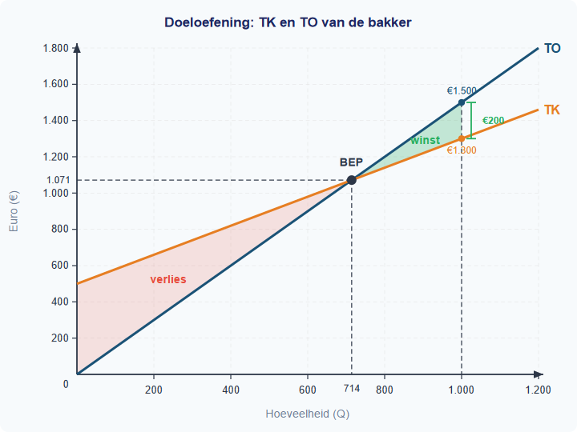

Doeloefening: TK en TO van de bakker met break-evenpunt en winstgebied

**Opgave 10 — Denkertje**

*Modelantwoord:*

**a)** Bij P = €1,50 en Q = 1000: TO = 1,50 x 1000 = €1.500 TK = 500 + 0,80 x 1000 = €1.300 Winst = 1.500 - 1.300 = **€200**

**b)** Verwachte afzet: 1000 x 1,30 = 1.300 broden. TO = 1,20 x 1300 = €1.560 TK = 500 + 0,80 x 1300 = 500 + 1.040 = €1.540 Winst = 1.560 - 1.540 = **€20**

**c)** De prijsverlaging is waarschijnlijk geen goed idee. De winst daalt van €200 naar €20 — een daling van 90%. De bakker verkoopt weliswaar 30% meer broden, maar de lagere prijs per brood kost meer dan de extra verkoop opbrengt.

Ontbrekende informatie: de bakker weet niet zeker dat de afzet precies 30% stijgt. Misschien stijgt de vraag meer of minder. Ook kan het zijn dat de concurrentie ook de prijs verlaagt, waardoor het effect kleiner is. Verder zou de bakker moeten nagaan of zijn productiecapaciteit 1300 broden aankan — misschien moet hij extra personeel aannemen (hogere constante kosten) of een grotere oven aanschaffen.

*Beoordelingscriteria:* - Correcte berekening van winst in beide scenario’s - Vergelijking van de twee winstbedragen met een conclusie - Minimaal een argument waarom het resultaat onzeker is (onbekende prijselasticiteit, concurrentiegedrag, capaciteitsgrenzen) - Erkenning dat meer informatie nodig is voor een definitieve beslissing

# Antwoorden §1.3.4 — Aanbod en kosten

## Opgave 1: Bakkerij “Korenveld”

**1** *(2 punten)*

Bij een productie van 800 croissants (uit tabel 1): - Variabele kosten = €1.100 - Totale kosten = €1.900

**Stap 1:** GVK = VK / Q = 1.100 / 800 = **€1,375 per croissant**

**Stap 2:** GTK = TK / Q = 1.900 / 800 = **€2,375 per croissant**

*Waarom:* GVK en GTK worden berekend door de totale (variabele) kosten te delen door de geproduceerde hoeveelheid. Het verschil tussen GTK en GVK is de gemiddelde constante kosten (GCK = 800 / 800 = €1,00).

**2** *(2 punten)*

Bij een productie van 1.000 croissants (uit tabel 1): - Totale opbrengst (TO) = €2.500 - Totale kosten (TK) = €2.400

Winst = TO − TK = 2.500 − 2.400 = **€100**

*Waarom:* Winst is het verschil tussen totale opbrengst en totale kosten. De totale opbrengst = prijs × hoeveelheid = €2,50 × 1.000 = €2.500, wat overeenkomt met de tabel.

**3** *(2 punten)*

Maaike draait **break-even tussen 600 en 800 croissants**. Uit tabel 1:

- Bij Q = 600: TO = €1.500, TK = €1.550 → verlies van €50
- Bij Q = 800: TO = €2.000, TK = €1.900 → winst van €100

Break-even betekent dat TO = TK (winst = 0). Dat punt ligt tussen 600 en 800 stuks — bij die productie zijn de opbrengsten precies gelijk aan de kosten.

*Waarom:* Break-even is het omslagpunt waar een bedrijf van verlies naar winst gaat. Uit de tabel blijkt dat de winst omslaat van negatief (−€50 bij 600) naar positief (+€100 bij 800).

**4** *(2 punten)*

Bereken de winst bij elk productieniveau (uit tabel 1):

| Productie | TO (€) | TK (€) | Winst (€) |
| --- | --- | --- | --- |
| 0 | 0 | 800 | −800 |
| 200 | 500 | 1.100 | −600 |
| 400 | 1.000 | 1.300 | −300 |
| 600 | 1.500 | 1.550 | −50 |
| 800 | 2.000 | 1.900 | +100 |
| 1.000 | 2.500 | 2.400 | +100 |
| 1.200 | 3.000 | 3.200 | −200 |

De winst is maximaal bij **800 of 1.000 croissants per maand**: beide geven een winst van **€100**.

*Waarom:* Om de maximale winst te vinden, bereken je bij elk productieniveau het verschil TO − TK. Het productieniveau met het hoogste verschil geeft de maximale winst. Er is hier geen marginale analyse nodig — je vergelijkt gewoon de winstcijfers in de tabel.

**5** *(2 punten)*

Bij 1.000 croissants maakt Maaike €100 winst (schakel 1). Bij 1.200 croissants stijgen de variabele kosten van €1.600 naar €2.400 — een stijging van €800 — terwijl de extra opbrengst slechts 200 × €2,50 = €500 bedraagt (schakel 2). De extra kosten zijn dus hoger dan de extra opbrengsten, waardoor de winst daalt van +€100 naar −€200: een verlies.

*Waarom:* Meer produceren is alleen verstandig als de extra opbrengst hoger is dan de extra kosten. Tussen 1.000 en 1.200 stuks stijgen de variabele kosten sneller dan de opbrengsten — de “sweet spot” is al voorbij.

**Denkertje — modelantwoord en beoordelingscriteria**

*Modelantwoord:* De uitspraak klopt niet. Uit tabel 1 blijkt dat de gemiddelde totale kosten (GTK) aanvankelijk dalen bij hogere productie, maar uiteindelijk weer stijgen:

- Bij 200 stuks: GTK = 1.100 / 200 = €5,50
- Bij 800 stuks: GTK = 1.900 / 800 = €2,375
- Bij 1.000 stuks: GTK = 2.400 / 1.000 = €2,40
- Bij 1.200 stuks: GTK = 3.200 / 1.200 = €2,67

Tot 800 stuks dalen de GTK doordat de constante kosten over meer eenheden worden verdeeld (degressief effect). Maar vanaf 800 stuks stijgen de GTK weer, doordat de variabele kosten sneller stijgen dan de productie toeneemt. Bovendien: zelfs als de GTK dalen, betekent dat niet automatisch meer winst — de winst hangt af van het verschil tussen prijs en GTK, én van de hoeveelheid. Bij 1.200 stuks zijn de GTK (€2,67) hoger dan de prijs (€2,50), waardoor Maaike verlies maakt.

*Beoordelingscriteria:* - Laat met cijfers uit tabel 1 zien dat GTK eerst dalen en daarna stijgen (1 pt) - Verbindt dit aan winst: lage GTK ≠ automatisch meer winst; bij te hoge productie kan verlies ontstaan (1 pt)

## Opgave 2: Fietsfabriek “VeloTech”

**6** *(2 punten)*

Uit tabel 2 (vóór staalstijging):

**TCK** = huur + afschrijving + salarissen = 200.000 + 80.000 + 120.000 = **€400.000**

**TVK** = staal + energie + verpakking = 500.000 + 50.000 + 100.000 = **€650.000**

*Waarom:* Constante kosten veranderen niet met de productieomvang (huur, afschrijving, vaste salarissen). Variabele kosten veranderen wel (grondstoffen, energie, verpakking). Je sorteert de kosten op type en telt per categorie op.

**7** *(2 punten)*

**Stap 1:** Totale kosten (TK) = TCK + TVK = 400.000 + 650.000 = €1.050.000

**Stap 2:** GTK = TK / Q = 1.050.000 / 5.000 = **€210 per fiets**

*Waarom:* De gemiddelde totale kosten geven aan hoeveel elke fiets gemiddeld kost om te produceren. De verkoopprijs is €230, dus vóór de staalstijging maakt VeloTech winst per fiets: €230 − €210 = €20.

**8** *(2 punten)*

De aanbodfactor die verandert is de **prijs van productiefactoren** (grondstoffen / inputprijzen).

Dit leidt tot een **verschuiving van de aanbodlijn naar links** (omhoog). De staalprijs is geen verandering van de eigen verkoopprijs van fietsen, maar een verandering van de productiekosten. Bij elke verkoopprijs kunnen producenten minder fietsen winstgevend aanbieden → de aanbodlijn verschuift naar links.

*Waarom:* Een beweging langs de aanbodlijn ontstaat alleen bij een verandering van de eigen prijs van het goed. Een verandering van inputprijzen is een aanbodfactor die de hele lijn verschuift.

**9** *(2 punten)*

**Vóór de staalstijging:** - TK = €1.050.000 (uit vraag 7) - TO = 5.000 × €230 = €1.150.000 - Winst per fiets = (TO − TK) / Q = (1.150.000 − 1.050.000) / 5.000 = **€20 per fiets**

**Ná de staalstijging:** - TVK nieuw = 700.000 + 50.000 + 100.000 = €850.000 - TK nieuw = 400.000 + 850.000 = €1.250.000 - TO = 5.000 × €230 = €1.150.000 (prijs onveranderd) - Winst per fiets = (1.150.000 − 1.250.000) / 5.000 = **−€20 per fiets (verlies)**

De stijging van de staalprijs verhoogt de variabele kosten met €200.000 (schakel 1). Omdat de verkoopprijs gelijk blijft, dalen de totale opbrengsten niet, maar stijgen de kosten wel — waardoor de winst per fiets daalt van €20 naar −€20 (schakel 2).

**10** *(3 punten)*

Als VeloTech de verkoopprijs verhoogt van €230 naar €270, is dit een **beweging langs de aanbodlijn**, geen verschuiving.

De aanbodlijn is na de staalstijging al naar links verschoven (vanwege hogere inputprijzen, zie vraag 8). De verkoopprijs is de prijs van het goed zelf. Als die prijs stijgt van €230 naar €270, beweegt VeloTech langs de (nieuwe, verschoven) aanbodlijn naar een punt met een hogere prijs en een hogere aangeboden hoeveelheid.

Het feit dat een concurrent vergelijkbare fietsen aanbiedt voor €250 betekent dat VeloTech bij €270 mogelijk klanten verliest — maar dat verandert niets aan het type verandering: een prijsverandering van het eigen goed is altijd een beweging langs de lijn.

*Waarom:* Twee stappen: (1) de staalstijging verschuift de hele aanbodlijn (aanbodfactor ≠ eigen prijs), (2) de prijsverhoging is een beweging langs die nieuwe lijn (eigen prijs verandert). Dit onderscheid is cruciaal: verschuiving = andere factor, beweging = eigen prijs.

**Puntenverdeling:** - Correct: beweging langs de aanbodlijn (1 pt) - Motivering: de verkoopprijs is de eigen prijs van het goed (1 pt) - Onderscheid met vraag 8: de staalstijging verschoof de lijn, de prijsverhoging is een beweging langs de verschoven lijn (1 pt)

**Denkertje — modelantwoord en beoordelingscriteria**

*Modelantwoord:* De uitspraak klopt niet altijd. Er zijn redenen waarom een bedrijf bij stijgende kosten de prijs niet verhoogt:

1. **Concurrentie:** Als concurrenten hun prijs niet verhogen (zoals de concurrent die €250 vraagt), verliest het bedrijf klanten bij een hogere prijs. In een markt met veel concurrentie kan een bedrijf gedwongen zijn de kostenstijging (deels) zelf te dragen.
2. **Alternatieve strategieën:** Een bedrijf kan ook kosten besparen op andere posten, efficiënter produceren, of tijdelijk minder winst accepteren om marktaandeel te behouden.
3. **Vraagreactie:** Als de vraag prijsgevoelig is, leidt een hogere prijs tot een sterke daling van de gevraagde hoeveelheid, waardoor de totale opbrengst kan dalen ondanks de hogere prijs per stuk.

De uitspraak gaat ervan uit dat bedrijven altijd alle kostenstijgingen kunnen doorberekenen, maar dat hangt af van de marktomstandigheden.

*Beoordelingscriteria:* - Noemt minstens één concrete reden waarom niet verhogen rationeel kan zijn (concurrentie, vraagelasticiteit, alternatieve besparingen) (1 pt) - Verbindt de reden aan de context of aan een economisch mechanisme (marktwerking, prijsgevoeligheid) (1 pt)